# Uygulama Notları: 6

## FİZ219 - Bilgisayar Programlama I | 15/11/2019

- 1. Ara Sınav Soru ve Çözümleri

Emre S. Tasci emre.tasci@hacettepe.edu.tr

**1. Soru:**

**a)** $\begin{bmatrix} 1 & 2 & 3 & 4 & 5 \\6 & 7 & 8 & 9 & 10\\ 11 & 12 & 13 & 14 & 15 \\16 & 17 & 18 & 19 & 20\end{bmatrix}$ ile verilen A matrisini Octave'da nasıl tanımlarsınız?

```matlab
A = [1:5; 6:10; 11:15; 16:20] % Güzel cevap

A = [1:5
6:10
11:15
16:20] % Eşdeğer güzellikte cevap
```

```
A =

    1    2    3    4    5
    6    7    8    9   10
   11   12   13   14   15
   16   17   18   19   20

A =

    1    2    3    4    5
    6    7    8    9   10
   11   12   13   14   15
   16   17   18   19   20
```

```matlab
A = [1 2 3 4 5
6 7 8 9 10
11 12 13 14 15
16 17 18 19 20] % Bariz cevap
```

```
A =

    1    2    3    4    5
    6    7    8    9   10
   11   12   13   14   15
   16   17   18   19   20
```

```matlab
A = [];
for satir = 1:4
    for sutun = 1:5
        A(satir,sutun) = (satir-1)*5 + sutun;
    endfor
endfor
A % İlginç cevap
```

```
A =

    1    2    3    4    5
    6    7    8    9   10
   11   12   13   14   15
   16   17   18   19   20
```

```matlab
A = reshape(1:20,5,4)' % Henüz görmediğiniz bir cevap ;)
```

```
A =

    1    2    3    4    5
    6    7    8    9   10
   11   12   13   14   15
   16   17   18   19   20
```

**b)** Bu matrisin $\begin{array}{cc} 8 & 9 \\ 18 & 19 \end{array}$ 'luk kesimine karşılık gelen kısmını B matrisi olarak nasıl atarsınız?

```matlab
B = A([2,4],3:4) % Güzel cevap
```

```
B =

    8    9
   18   19
```

```matlab
B = A([2,4],[3,4]) % Normal cevap
```

```
B =

    8    9
   18   19
```

```matlab
B = [A(2,3) A(2,4); A(4,3) A(4,4)] % Zorlama cevap
```

```
B =

    8    9
   18   19
```

**2. Soru**

Aşağıdaki satırlar sırası ile girildiğinde, her bir satırdan sonraki çıktıyı yazınız:

```matlab
m = 1:pi
```

```
m =

   1   2   3
```

```matlab
[1:4].^2*2
```

```
ans =

    2    8   18   32
```

```matlab
a = 2;
```

```matlab
% a = 5
```

```matlab
b = a + 4
```

```
b =  6
```

**3. Soru**

$-\pi\le\theta\le3\pi$ değer aralığında, en az 100 değer kullanarak $\sin{(\theta)}$ fonksiyonunun grafiğini çizdirin.

*Bonus:* $\sin{(\theta)}$ ile birlikte aynı grafikte $\cos{(\theta)}$ fonksiyonunu da çizdirin.

*Bonusun bonusu:* sin grafiğini sadece noktalı ve kırmızı; cos grafiğini ise kesikli çizgili ve mavi çizdirin.

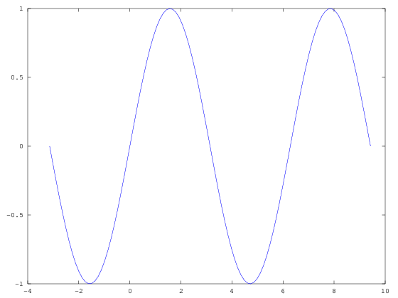

```matlab
%theta = -pi:0.125:3*pi; % Normal aralık tanımı
theta = linspace(-pi,3*pi,100); % Güzel aralık tanımı
sinler = sin(theta);
plot(theta,sinler)
```

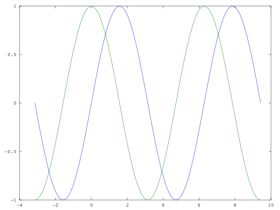

```matlab
koslar = cos(theta);
plot(theta,sinler,theta,koslar)
```

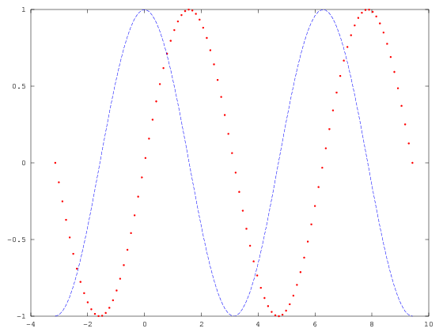

```matlab
plot(theta,sinler,".r",theta,koslar,"--b")
```

**4. Soru:**

Aşağıdaki program çalıştığında ekrana neler yazılacaktır?

```matlab
y = 0;
k = 2;
x = 19;
if(k<5)
    while(x<20)
        x = 30 - k.^2;
        y = x + 2;
    endwhile
else
    y = 6;
endif
y
```

```
y =  28
```

**5. Soru:**

[6, 30] (yani $6\le x\le30$) aralığındaki tam sayıları toplayan bir program yazın.

```matlab
s = sum(6:30) % Güzel cevap
```

```
s =  450
```

```matlab
s = 0;
for x = 6:30
    s = s + x;
endfor
s % Normal cevap
```

```
s =  450
```

```matlab
s = 6+7+8+9+10+11+12+13+14+15+16+17+18+19+20+21+22+23+24+25+...
26+27+28+29+30 % Korkunç cevap (!!!)
```

```
s =  450
```

**Bonus Soru:**

$x_1 = 0$ ve $x_2 = 1$ ile başlayıp, sonraki elemanları $x_i = x_{i-2} + x_{i-1}$ şeklinde hesaplanan (0, 1, 1, 2, 3, 5, 8, 13, ...) sayı dizisine *Fibonacci dizisi* denmekte olup, doğada bu örüntü (*pattern*) sık sık karşımıza çıkar. İlk 100 Fibonacci sayısını hesaplayıp, onları `fibonacci` adındaki bir listede toplayan bir program yazın.

```matlab
fibonacci = [0 1];
for i=3:100
    fibonacci(i) = fibonacci(i-2) + fibonacci(i-1);
endfor
fibonacci(1:10) % ilk 10 terim
fibonacci(98:100) % son 3 terim
```

```
ans =

    0    1    1    2    3    5    8   13   21   34

ans =

   8.3621e+19   1.3530e+20   2.1892e+20
```

İlerki derslerde fonksiyonları görünce, bu diziyi çok daha ince, güzel ve zarif bir yolla ("tekrarlı/rekürsif") hesaplamayı öğreneceğiz. ;)